# Group Project: Data Pre-Processing

```python
import numpy as np
import pandas as pd
import matplotlib.pyplot as plt
from sklearn.model_selection import train_test_split
from scipy.stats import zscore
```

### Original Data Set Link

https://www.kaggle.com/iabhishekofficial/mobile-price-classification?select=train.csv

```python
pData = pd.read_csv('../data/mobile_phone_train_original.csv')
```

```python
pData.shape
```

```
(2000, 21)
```

```python
pData
```

|  | battery_power | blue | clock_speed | dual_sim | fc | four_g | int_memory | m_dep | mobile_wt | n_cores | ... | px_height | px_width | ram | sc_h | sc_w | talk_time | three_g | touch_screen | wifi | price_range |
| --- | --- | --- | --- | --- | --- | --- | --- | --- | --- | --- | --- | --- | --- | --- | --- | --- | --- | --- | --- | --- | --- |
| 0 | 842 | 0 | 2.2 | 0 | 1 | 0 | 7 | 0.6 | 188 | 2 | ... | 20 | 756 | 2549 | 9 | 7 | 19 | 0 | 0 | 1 | 1 |
| 1 | 1021 | 1 | 0.5 | 1 | 0 | 1 | 53 | 0.7 | 136 | 3 | ... | 905 | 1988 | 2631 | 17 | 3 | 7 | 1 | 1 | 0 | 2 |
| 2 | 563 | 1 | 0.5 | 1 | 2 | 1 | 41 | 0.9 | 145 | 5 | ... | 1263 | 1716 | 2603 | 11 | 2 | 9 | 1 | 1 | 0 | 2 |
| 3 | 615 | 1 | 2.5 | 0 | 0 | 0 | 10 | 0.8 | 131 | 6 | ... | 1216 | 1786 | 2769 | 16 | 8 | 11 | 1 | 0 | 0 | 2 |
| 4 | 1821 | 1 | 1.2 | 0 | 13 | 1 | 44 | 0.6 | 141 | 2 | ... | 1208 | 1212 | 1411 | 8 | 2 | 15 | 1 | 1 | 0 | 1 |
| ... | ... | ... | ... | ... | ... | ... | ... | ... | ... | ... | ... | ... | ... | ... | ... | ... | ... | ... | ... | ... | ... |
| 1995 | 794 | 1 | 0.5 | 1 | 0 | 1 | 2 | 0.8 | 106 | 6 | ... | 1222 | 1890 | 668 | 13 | 4 | 19 | 1 | 1 | 0 | 0 |
| 1996 | 1965 | 1 | 2.6 | 1 | 0 | 0 | 39 | 0.2 | 187 | 4 | ... | 915 | 1965 | 2032 | 11 | 10 | 16 | 1 | 1 | 1 | 2 |
| 1997 | 1911 | 0 | 0.9 | 1 | 1 | 1 | 36 | 0.7 | 108 | 8 | ... | 868 | 1632 | 3057 | 9 | 1 | 5 | 1 | 1 | 0 | 3 |
| 1998 | 1512 | 0 | 0.9 | 0 | 4 | 1 | 46 | 0.1 | 145 | 5 | ... | 336 | 670 | 869 | 18 | 10 | 19 | 1 | 1 | 1 | 0 |
| 1999 | 510 | 1 | 2.0 | 1 | 5 | 1 | 45 | 0.9 | 168 | 6 | ... | 483 | 754 | 3919 | 19 | 4 | 2 | 1 | 1 | 1 | 3 |

2000 rows × 21 columns

```python
pData.columns
```

```
Index(['battery_power', 'blue', 'clock_speed', 'dual_sim', 'fc', 'four_g',
       'int_memory', 'm_dep', 'mobile_wt', 'n_cores', 'pc', 'px_height',
       'px_width', 'ram', 'sc_h', 'sc_w', 'talk_time', 'three_g',
       'touch_screen', 'wifi', 'price_range'],
      dtype='object')
```

### Variable Descriptions

battery_power: Total energy a battery can store in one time measured in mAh.

blue: Has bluetooth or not.

clock_speed: Speed at which microprocessor executes instructions

dual_sim: Has dual sim support or not

fc: Front camera megapixels

four_g: Has 4G or not

int_memory: nternal memory in Gigabytes

m_dep: Mobile depth in cm

mobile_wt: Weight of mobile phone

n_cores: Number of cores of processor

pc: Primary camera megapixels

px_height: Pixel Resolution Height

px_width: Pixel Resolution Width

ram: Random Access Memory in Megabytes

sc_h: Screen Height of mobile in cm

sc_w: Screen Width of mobile in cm

talk_time: Longest time that a single battery charge will last when talking on phone, in hours

three_g: Has 3G or not

touch_screen: Has touch screen or not

wifi: Has wifi or not

price_range: This is the target variable with value of 0(low cost), 1(medium cost), 2(high cost), and 3(very high cost)

## General Characteristics

#### Look at the characteristics of each of the variables.

#### Numeric variables: count, mean, standard deviation, minimum, quartiles, and the maximum.

The data set conveniently has all numerical data types. There are some boolean variables(blue, wifi, touch_screen, etc.) that are represented by 0's and 1's in the original data set. The other variables are continuous(int_memory, mobile_wt, etc.) or discrete (n_cores, pc, etc.).

```python
pData.describe()
```

|  | battery_power | blue | clock_speed | dual_sim | fc | four_g | int_memory | m_dep | mobile_wt | n_cores | ... | px_height | px_width | ram | sc_h | sc_w | talk_time | three_g | touch_screen | wifi | price_range |
| --- | --- | --- | --- | --- | --- | --- | --- | --- | --- | --- | --- | --- | --- | --- | --- | --- | --- | --- | --- | --- | --- |
| count | 2000.000000 | 2000.0000 | 2000.000000 | 2000.000000 | 2000.000000 | 2000.000000 | 2000.000000 | 2000.000000 | 2000.000000 | 2000.000000 | ... | 2000.000000 | 2000.000000 | 2000.000000 | 2000.000000 | 2000.000000 | 2000.000000 | 2000.000000 | 2000.000000 | 2000.000000 | 2000.000000 |
| mean | 1238.518500 | 0.4950 | 1.522250 | 0.509500 | 4.309500 | 0.521500 | 32.046500 | 0.501750 | 140.249000 | 4.520500 | ... | 645.108000 | 1251.515500 | 2124.213000 | 12.306500 | 5.767000 | 11.011000 | 0.761500 | 0.503000 | 0.507000 | 1.500000 |
| std | 439.418206 | 0.5001 | 0.816004 | 0.500035 | 4.341444 | 0.499662 | 18.145715 | 0.288416 | 35.399655 | 2.287837 | ... | 443.780811 | 432.199447 | 1084.732044 | 4.213245 | 4.356398 | 5.463955 | 0.426273 | 0.500116 | 0.500076 | 1.118314 |
| min | 501.000000 | 0.0000 | 0.500000 | 0.000000 | 0.000000 | 0.000000 | 2.000000 | 0.100000 | 80.000000 | 1.000000 | ... | 0.000000 | 500.000000 | 256.000000 | 5.000000 | 0.000000 | 2.000000 | 0.000000 | 0.000000 | 0.000000 | 0.000000 |
| 25% | 851.750000 | 0.0000 | 0.700000 | 0.000000 | 1.000000 | 0.000000 | 16.000000 | 0.200000 | 109.000000 | 3.000000 | ... | 282.750000 | 874.750000 | 1207.500000 | 9.000000 | 2.000000 | 6.000000 | 1.000000 | 0.000000 | 0.000000 | 0.750000 |
| 50% | 1226.000000 | 0.0000 | 1.500000 | 1.000000 | 3.000000 | 1.000000 | 32.000000 | 0.500000 | 141.000000 | 4.000000 | ... | 564.000000 | 1247.000000 | 2146.500000 | 12.000000 | 5.000000 | 11.000000 | 1.000000 | 1.000000 | 1.000000 | 1.500000 |
| 75% | 1615.250000 | 1.0000 | 2.200000 | 1.000000 | 7.000000 | 1.000000 | 48.000000 | 0.800000 | 170.000000 | 7.000000 | ... | 947.250000 | 1633.000000 | 3064.500000 | 16.000000 | 9.000000 | 16.000000 | 1.000000 | 1.000000 | 1.000000 | 2.250000 |
| max | 1998.000000 | 1.0000 | 3.000000 | 1.000000 | 19.000000 | 1.000000 | 64.000000 | 1.000000 | 200.000000 | 8.000000 | ... | 1960.000000 | 1998.000000 | 3998.000000 | 19.000000 | 18.000000 | 20.000000 | 1.000000 | 1.000000 | 1.000000 | 3.000000 |

8 rows × 21 columns

```python
pData.dtypes
```

```
battery_power      int64
blue               int64
clock_speed      float64
dual_sim           int64
fc                 int64
four_g             int64
int_memory         int64
m_dep            float64
mobile_wt          int64
n_cores            int64
pc                 int64
px_height          int64
px_width           int64
ram                int64
sc_h               int64
sc_w               int64
talk_time          int64
three_g            int64
touch_screen       int64
wifi               int64
price_range        int64
dtype: object
```

## Visualizations

#### Look at different plots of the data.

#### Numerical variables: Box plots, scatter plots, and histograms

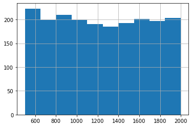

```python
pData["battery_power"].hist(bins=10)
```

Battery Power seems to be relatively uniform ranging from 500 millamps per hour to 2000 milliamps per hour. It would be interesting to see this compared to features in the phone. The number of features in the phone could indicate more usage of battery power (including in the background) as well as further advancement in technology in the phone and therefore greater battery technology in the phone.

In order to group battery power we will bin the variable into 3 groupds. Low being the lowest battery power and high being the highest.

```python
bin_Labels = ["Low","Medium","High"]
# Cut intervals will be (500,1000], [1001,1500], [1501,2000]
batt_bins = pd.cut(pData.battery_power,[500,1000,1500,2000],labels=bin_Labels)
pData["battery_power_bins"] = batt_bins
```

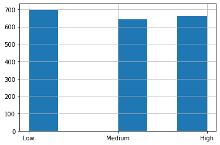

```python
pData["battery_power_bins"].hist(bins=6)
```

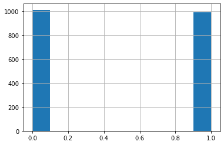

```python
pData["blue"].hist(bins=10)
```

There are an even number of cell phones that have blue tooth and dont. The first phone that had bluetooth was available in 2001. The first iPhone to have bluetooth, the iPhone 4S, came out in 2011.

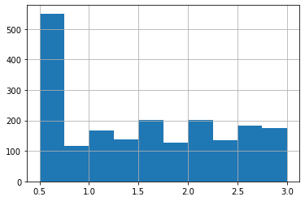

```python
pData["clock_speed"].hist(bins=10)
```

There is an unproportionately large number of phones that have a microprocessor that executes tasks in .5 seconds. This may indicate a standard for smart phones or a level at which a phone really performs best. Certain specs or technological adds ons may need the microprocessor in the phone to be quicker.

For cross tabulation purposes later, we will bin the clock_speed into slow, medium, fast.

```python
pData.clock_speed.describe()
```

```
count    2000.000000
mean        1.522250
std         0.816004
min         0.500000
25%         0.700000
50%         1.500000
75%         2.200000
max         3.000000
Name: clock_speed, dtype: float64
```

```python
bin_Labels = ["Slow","Medium","Fast"]
clock_bins = pd.cut(pData.clock_speed,[.4,1.33,2.166,3.1],labels=bin_Labels)
pData["clock_speed_bins"] = clock_bins
```

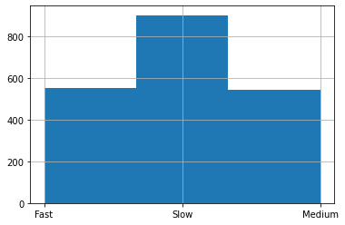

```python
pData["clock_speed_bins"].hist(bins=3)
```

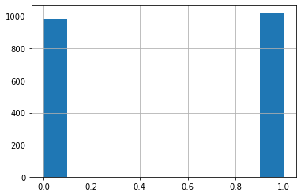

```python
pData["dual_sim"].hist(bins=10)
```

The split between having a dual sim card or not seems to be relatively even.

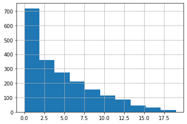

```python
pData["fc"].hist(bins=10)
```

The front camera megapixels shows an exponential decay distribution. This could indicate expensive technology. Either phones don't have front cameras at all or they have the technology but it is still costly so only a few have the best technology included. Front facing cameras may also be rare. The iPhone 4, which came out in 2010 was the first iPhone to have a front facing camera.

For crosstab analysis later, we will bin the front camer megapixels variable into two categories.

```python
bin_Labels = [">10","<10"]
fc_bins = pd.cut(pData.fc,[-1,10,20],labels=bin_Labels)
pData["fc_bins"] = fc_bins
```

[figure not shown]

```python
pData["fc_bins"].hist(bins=3)
```

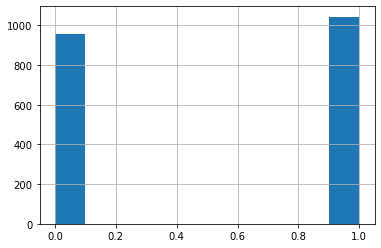

```python
pData["four_g"].hist(bins=10)
```

An phone hacing 4G technology currently seems to be close to a 50/50 chance.

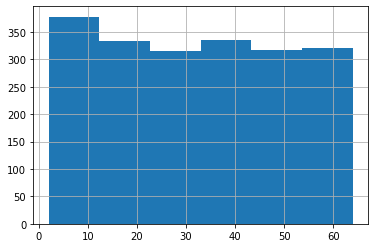

```python
pData["int_memory"].hist(bins=6)
```

Internal Memory in gigabytes in the phones appears to range from 2 to 64. Six bins were chosen for this histrogram because gigabytes typically come in 2,4,8,16,32 and 64. There is a relatively uniform distribution with slightly more phones in the 2-8 GB range. This could be a result of non-smart phones that still need some memory but need very minimal.

```python
bin_Labels = ["Low","Med","High"]
int_memory_bins = pd.cut(pData.int_memory,[0,22,44,65],labels=bin_Labels)
pData["int_memory_bins"] = int_memory_bins
```

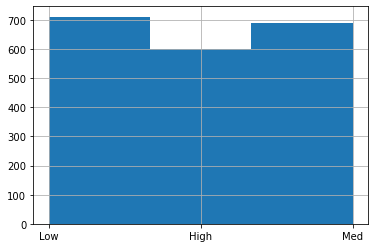

```python
pData["int_memory_bins"].hist(bins=3)
```

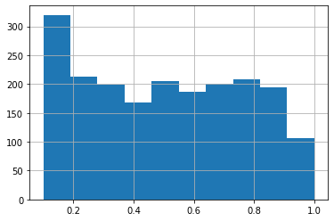

```python
pData["m_dep"].hist(bins=10)
```

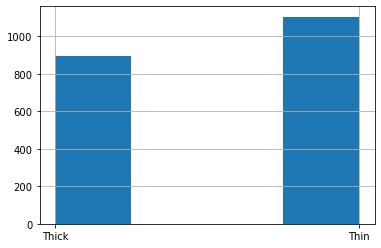

```python
bin_Labels = ["Thin","Thick"]
m_dep_bins = pd.cut(pData.m_dep,[0,.5,1],labels=bin_Labels)
pData["m_dep_bins"] = m_dep_bins
pData["m_dep_bins"].hist(bins=4)
```

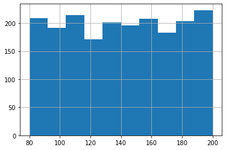

```python
pData["mobile_wt"].hist(bins=10)
```

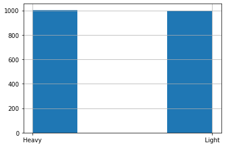

```python
bin_Labels = ["Light","Heavy"]
mobile_wt_bins = pd.cut(pData.mobile_wt,[0,140,200],labels=bin_Labels)
pData["mobile_wt_bins"] = mobile_wt_bins
pData["mobile_wt_bins"].hist(bins=4)
```

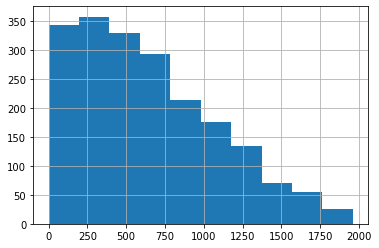

```python
pData["px_height"].hist(bins=10)
```

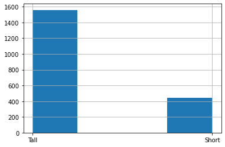

```python
variable = "px_height_bins"
bin_Labels = ["Tall","Short"]
bins = pd.cut(pData.px_height,[-1,1000,2001],labels=bin_Labels)
pData[variable] = bins
pData[variable].hist(bins=4)
```

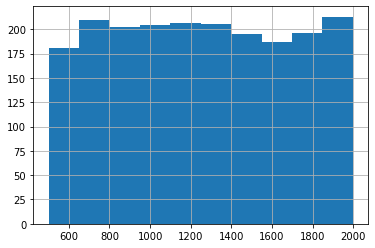

```python
pData["px_width"].hist(bins=10)
```

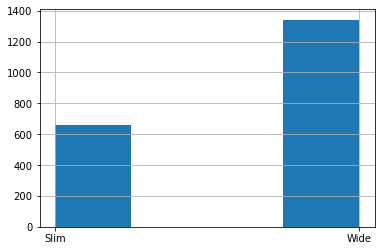

```python
variable = "px_width_bins"
bin_Labels = ["Slim","Wide"]
bins = pd.cut(pData.px_width,[-1,1000,2001],labels=bin_Labels)
pData[variable] = bins
pData[variable].hist(bins=4)
```

Feature engineering to capture the area of the pixels of the phone instead of having two separate variables for the height and the width

```python
pData["pixel_area_000s"] = (pData.px_height * pData.px_width)/1000
```

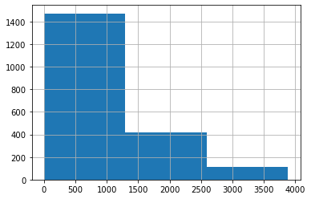

```python
pData["pixel_area_000s"].hist(bins=3)
```

```python
pData.pixel_area_000s.describe()
```

```
count    2000.000000
mean      905.260053
std       829.762497
min         0.000000
25%       263.200500
50%       601.359000
75%      1359.027250
max      3886.306000
Name: pixel_area_000s, dtype: float64
```

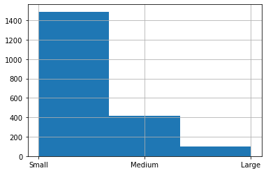

```python
variable = "pixel_area_bins"
bin_Labels = ["Small","Medium", "Large"]
bins = pd.cut(pData.pixel_area_000s,[-1,1333,2666,4001],labels=bin_Labels)
pData[variable] = bins
pData[variable].hist(bins=3)
```

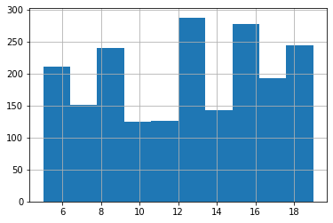

```python
pData["sc_h"].hist(bins=10)
```

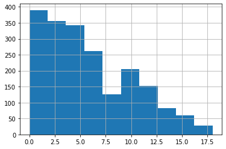

```python
pData["sc_w"].hist(bins=10)
```

Feature Engineering to capture the height and the width of the screen in a single variable which is the area of the screen. The two variables give us an idea of the size of the phone which is also given to us in a more straight forward manner with the area of the screen.

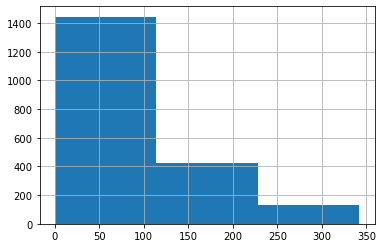

```python
pData["screen_area"] = pData.sc_h * pData.sc_w
pData["screen_area"].hist(bins=3)
```

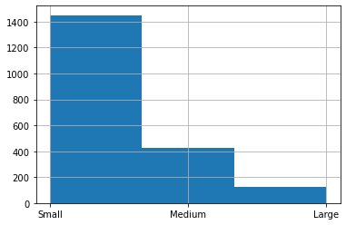

```python
variable = "screen_area_bins"
bin_Labels = ["Small","Medium", "Large"]
bins = pd.cut(pData.screen_area,[-1,116,233,351],labels=bin_Labels)
pData[variable] = bins
pData[variable].hist(bins=3)
```

Phone depth, width, screen height, and screen width may be interesting to compare and try to derive a timeframe from. The size of phones, which impacts each of the 4 previous mentioned variables, has fluctuated over the years. Phones started out large in order to hold eachnology. As time went on and phone parts became smaller, so did the phones and this showed that you had a new phone with the latest technology so the smaller the phone, the better. Then, times switched due to the amount of technology actually in the phone. People began carrying around little computer in their hand and therefore the desire to have a decent sized screen grew. With streaming capabilities and the different tasks a person could get done, phones almost grew to the size of mini tablets. Now, it seems that the trend is going back down and the desire to have a large phone is beginning to subside.

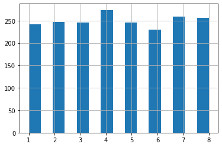

```python
pData["n_cores"].hist(bins=15)
```

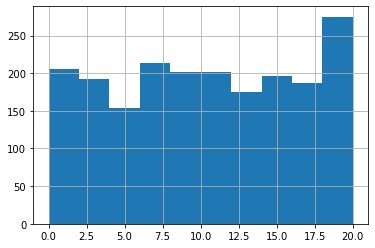

```python
pData["pc"].hist(bins=10)
```

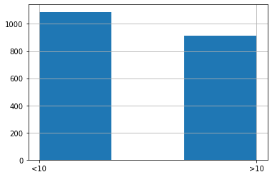

```python
variable = "pc_bins"
bin_Labels = ["<10",">10"]
bins = pd.cut(pData.pc,[-1,10,21],labels=bin_Labels)
pData[variable] = bins
pData[variable].hist(bins=3)
```

Having a decent primary camera on a cell phone is realtively essential now. It is not surprising to see that there is a spike at 20 mega pixels. However, comparing this to the front facing camera, is is shocking in the sense that the distribution is so different. As mentioned before, front facing cameras are newer than primary cameras so this could be a factor.

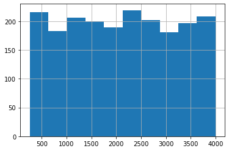

```python
pData["ram"].hist(bins=10)
```

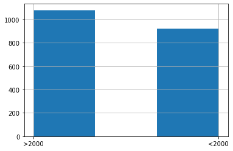

```python
variable = "ram_bins"
bin_Labels = ["<2000",">2000"]
bins = pd.cut(pData.ram,[-1,2000,4001],labels=bin_Labels)
pData[variable] = bins
pData[variable].hist(bins=3)
```

The distribution for RAM in cell phones is uniform across this dataset. RAM is often considered for computers and tablets but I am not sure that RAM is a spec that many people seek out when purchasing a phone. For this reason it could be something that the cell phone maker could fluctuate in order to help their bottom line.

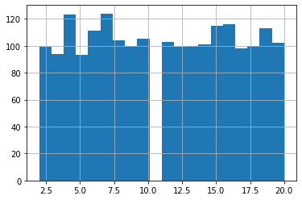

```python
pData["talk_time"].hist(bins=20)
```

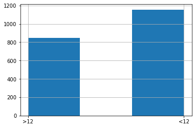

```python
variable = "talk_time_bins"
bin_Labels = ["<12",">12"]
bins = pd.cut(pData.talk_time,[-1,12,24.5],labels=bin_Labels)
pData[variable] = bins
pData[variable].hist(bins=3)
```

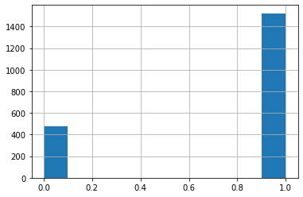

```python
pData["three_g"].hist(bins=10)
```

3G is older technology than 4G. This may be strongly correlated with 4G given that if a phone has 4G, they most certainly have 3G. This may be a variable that we are able to remove from our data set.

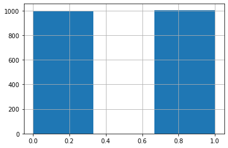

```python
pData["touch_screen"].hist(bins=3)
```

Touch screen will be an important variable because touch screen technology wasnt heavily used until the release of the iPhone 1 in 2007. Prior to that, a notable touch screen phone on the market was the Nokia 7710 which was released in 2004.Toucch screen realyl became a standard after the iPhone was released which gives a clear line between phones pre-iPhone and phones post-iPhone.

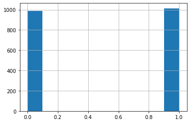

```python
pData["wifi"].hist(bins=10)
```

It is surprising to see that the split between phones with wifi and without wifi is 50/50. Connectivity to Wifi seems to be a standard in todays world so there may be a decent number of phones in this dataset that are pre-smart phones

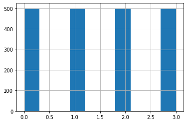

```python
pData["price_range"].hist(bins=10)
```

Price_Range is the target variable. Given that this data is relatively clean, it is nice to know that there is an even number of phones in each price range bucket as well. We are hopeful that we can derive some great insights into phone pricing because of this data set.

### Cross tabulations with price range and the different variables

```python
CT = pd.crosstab(pData["price_range"], pData["battery_power_bins"])
CT
```

| battery_power_bins price_range | Low | Medium | High |
| --- | --- | --- | --- |
| 0 | 226 | 167 | 107 |
| 1 | 169 | 178 | 153 |
| 2 | 187 | 139 | 174 |
| 3 | 115 | 157 | 228 |

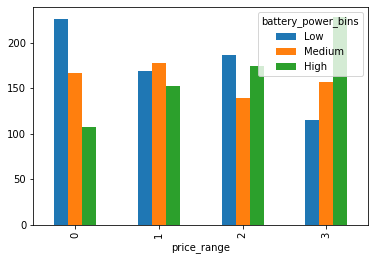

```python
plt.show(CT.plot(kind="bar"))
```

It is evident from the cross tabulation bar graph that when phones are cheaper, they have lower battery power and when they are more expensive, they have higher battery power. Battery power is essential and a very important consideration when purchasing a phone. If buying a use phone, even if the phone is very advanced if the battery doesnt last very long, you won't really be able to use the features of the phone anyways so it brings the price of the phone way down. In the two middle rice ranges of groups 1 and 2, there may be a mix of this occuring. Battery life may be moderate but the technology is good or bad or the battery life is really good or really bad but the phone the techology is opposite.

```python
CT = pd.crosstab(pData["price_range"], pData["blue"])
CT
```

| blue price_range | 0 | 1 |
| --- | --- | --- |
| 0 | 257 | 243 |
| 1 | 255 | 245 |
| 2 | 257 | 243 |
| 3 | 241 | 259 |

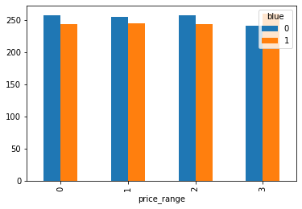

```python
plt.show(CT.plot(kind="bar"))
```

Blue tooth again ia very uniform across the phones. For price ranges 0-2, it seems that blue tooth is not a big factor in price. However, for price range 3, it appears that bluetooth may play a role since there are more phones with blue tooth than without.

However, given that there doesnt seem to be much variance in bluetooth across the four price range categories, this may not be a good variable to predict the price of a phone

```python
CT = pd.crosstab(pData["price_range"], pData["clock_speed_bins"])
CT
```

| clock_speed_bins price_range | Slow | Medium | Fast |
| --- | --- | --- | --- |
| 0 | 220 | 124 | 156 |
| 1 | 240 | 128 | 132 |
| 2 | 221 | 147 | 132 |
| 3 | 222 | 144 | 134 |

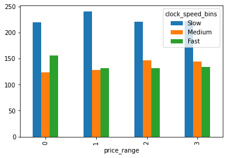

```python
plt.show(CT.plot(kind="bar"))
```

Phones in the lowest price range have a spike in fast microprocessor execution times. This is surprising, but this may be a result of less technology and less computationally expensive functionality. Otherwise, the clock_speed variable seems to be relatively uniform across all four price ranges.

```python
CT = pd.crosstab(pData["price_range"], pData["dual_sim"])
CT
```

| dual_sim price_range | 0 | 1 |
| --- | --- | --- |
| 0 | 250 | 250 |
| 1 | 245 | 255 |
| 2 | 251 | 249 |
| 3 | 235 | 265 |

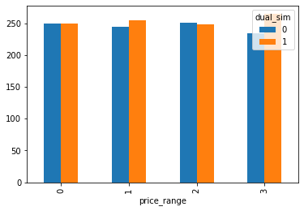

```python
plt.show(CT.plot(kind="bar"))
```

In the highest price range, the proportion of phones with dual sims and without is the highest but still it does not appear to be a large difference compared to the other price range groups.

```python
CT = pd.crosstab(pData["price_range"], pData["fc_bins"])
CT
```

| fc_bins price_range | >10 | <10 |
| --- | --- | --- |
| 0 | 450 | 50 |
| 1 | 440 | 60 |
| 2 | 445 | 55 |
| 3 | 444 | 56 |

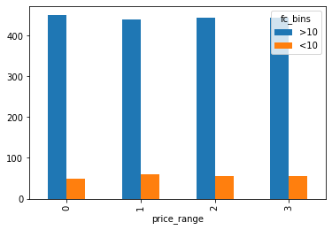

```python
plt.show(CT.plot(kind="bar"))
```

```python
CT = pd.crosstab(pData["price_range"], pData["four_g"])
CT
```

| four_g price_range | 0 | 1 |
| --- | --- | --- |
| 0 | 241 | 259 |
| 1 | 238 | 262 |
| 2 | 253 | 247 |
| 3 | 225 | 275 |

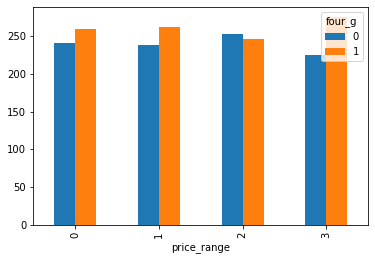

```python
plt.show(CT.plot(kind="bar"))
```

While the vairance across price ranges isn't too significant for th 4G indicator, the most expensive class still have significantly more than the other price ranges. It how has a larger proportion of 4G to no 4G, so this may in fact be a good indicator for price.

```python
CT = pd.crosstab(pData["price_range"], pData["int_memory_bins"])
CT
```

| int_memory_bins price_range | Low | Med | High |
| --- | --- | --- | --- |
| 0 | 185 | 169 | 146 |
| 1 | 176 | 177 | 147 |
| 2 | 196 | 159 | 145 |
| 3 | 154 | 185 | 161 |

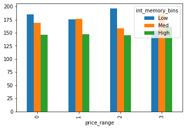

```python
plt.show(CT.plot(kind="bar"))
```

Internal memory in general is higher in the more expensive phones. This makes sense since when you are looking at a specific phone model, prices go up as the gb of the phone increase. While the variance doesnt appear to be significantly different between price ranges, there is still enough that this may be a decent predictor.

```python
CT = pd.crosstab(pData["price_range"], pData["m_dep_bins"])
CT
```

| m_dep_bins price_range | Thin | Thick |
| --- | --- | --- |
| 0 | 286 | 214 |
| 1 | 264 | 236 |
| 2 | 280 | 220 |
| 3 | 275 | 225 |

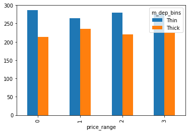

```python
plt.show(CT.plot(kind="bar"))
```

Depth of the phone does not appear to be too different between price ranges

```python
CT = pd.crosstab(pData["price_range"], pData["mobile_wt_bins"])
CT
```

| mobile_wt_bins price_range | Light | Heavy |
| --- | --- | --- |
| 0 | 246 | 254 |
| 1 | 249 | 251 |
| 2 | 228 | 272 |
| 3 | 273 | 227 |

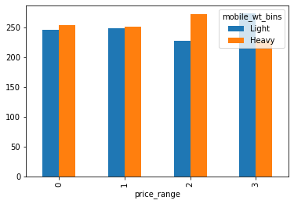

```python
plt.show(CT.plot(kind="bar"))
```

The most expensive price range has the lightest phones which is intuitive. Consumers typically want lighter phones as opposed to heavier phones that they need to carry around in their pocket. the lighter the phone, the more appealing it is to the buyer.

```python
CT = pd.crosstab(pData["price_range"], pData["n_cores"])
CT
```

| n_cores price_range | 1 | 2 | 3 | 4 | 5 | 6 | 7 | 8 |
| --- | --- | --- | --- | --- | --- | --- | --- | --- |
| 0 | 49 | 69 | 62 | 67 | 59 | 61 | 66 | 67 |
| 1 | 76 | 59 | 69 | 76 | 51 | 54 | 55 | 60 |
| 2 | 52 | 57 | 56 | 73 | 66 | 57 | 69 | 70 |
| 3 | 65 | 62 | 59 | 58 | 70 | 58 | 69 | 59 |

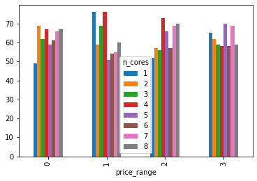

```python
plt.show(CT.plot(kind="bar"))
```

The cross tabulation of the number of cores compared to price range does not elude to any significant differences between thr different bins. The expectation is that there would be more cores in the more expensive phones but give the wide range of years and the way technology has gotten cheaper, this may not be as strong of an indicator as I was expecting.

```python
CT = pd.crosstab(pData["price_range"], pData["pc_bins"])
CT
```

| pc_bins price_range | <10 | >10 |
| --- | --- | --- |
| 0 | 279 | 221 |
| 1 | 278 | 222 |
| 2 | 267 | 233 |
| 3 | 264 | 236 |

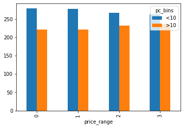

```python
plt.show(CT.plot(kind="bar"))
```

The primary camera megapixels does not show significant variance between the different price range buckets

```python
CT = pd.crosstab(pData["price_range"], pData["pixel_area_bins"])
CT
```

| pixel_area_bins price_range | Small | Medium | Large |
| --- | --- | --- | --- |
| 0 | 421 | 75 | 4 |
| 1 | 374 | 99 | 27 |
| 2 | 372 | 107 | 21 |
| 3 | 323 | 132 | 45 |

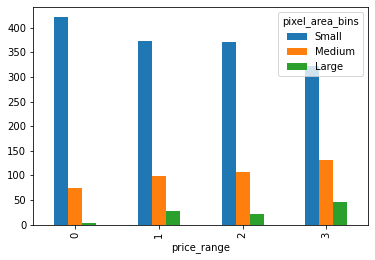

```python
plt.show(CT.plot(kind="bar"))
```

There seems to a decent amount of variance between the area of pixels and the price range of phones. However, the result of less expensive phones having small pixels than cheaper phones is suprising. The smaller the pixels, the better. It would make more sense that more expensive phones have smaller pixels but for the small pixel category that is not what is shown. It holds true for the large and medium pixel categories, but more analysis may need to be done for the this variable to understand it more

```python
CT = pd.crosstab(pData["price_range"], pData["ram_bins"])
CT
```

| ram_bins price_range | <2000 | >2000 |
| --- | --- | --- |
| 0 | 500 | 0 |
| 1 | 362 | 138 |
| 2 | 58 | 442 |
| 3 | 0 | 500 |

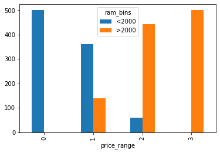

```python
plt.show(CT.plot(kind="bar"))
```

The RAM MB looks like it will be a greater indicator of price. The more RAM, the more expensive the phone. Cheap phones don't have over 2000 MB of RAM where expensive phones don't have less than 2000 MB of RAM.

```python
CT = pd.crosstab(pData["price_range"], pData["screen_area_bins"])
CT
```

| screen_area_bins price_range | Small | Medium | Large |
| --- | --- | --- | --- |
| 0 | 371 | 106 | 23 |
| 1 | 367 | 102 | 31 |
| 2 | 376 | 98 | 26 |
| 3 | 336 | 122 | 42 |

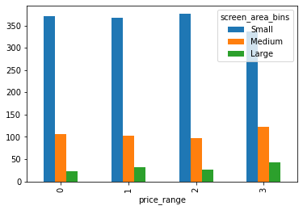

```python
plt.show(CT.plot(kind="bar"))
```

The variance between the price categories in regards to the area of the screen is not significant. This may be a result of the fluctuating consumer choices when it comes to if they want a bigger phone or a smaller phone. It could also be that phones are such an integral part of our daily lives that everyone has a preference and the choice is spread out enough across the population that size does not necessarily impact the price of a used phone.

```python
CT = pd.crosstab(pData["price_range"], pData["talk_time_bins"])
CT
```

| talk_time_bins price_range | <12 | >12 |
| --- | --- | --- |
| 0 | 305 | 195 |
| 1 | 274 | 226 |
| 2 | 284 | 216 |
| 3 | 292 | 208 |

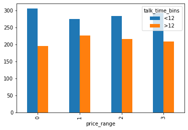

```python
plt.show(CT.plot(kind="bar"))
```

Talk time does not appear to impact the price range of a phone. However, with that said, when talk time is very low, more of these phone are in the cheap price range.

```python
CT = pd.crosstab(pData["price_range"], pData["three_g"])
CT
```

| three_g price_range | 0 | 1 |
| --- | --- | --- |
| 0 | 127 | 373 |
| 1 | 122 | 378 |
| 2 | 113 | 387 |
| 3 | 115 | 385 |

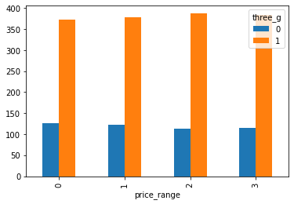

```python
plt.show(CT.plot(kind="bar"))
```

There is no significant variance across price ranges for 3G technology.

```python
CT = pd.crosstab(pData["price_range"], pData["touch_screen"])
CT
```

| touch_screen price_range | 0 | 1 |
| --- | --- | --- |
| 0 | 238 | 262 |
| 1 | 239 | 261 |
| 2 | 265 | 235 |
| 3 | 252 | 248 |

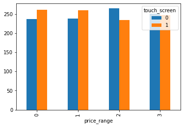

```python
plt.show(CT.plot(kind="bar"))
```

This crosstabulation is surprising because touch screen technology is newer than non-touchscreen, or simply buttons. In the expensive category, there appears to be more non touch screen than touch screen phones which is particularily interesting. Is it possible that this data has "antique" phones

```python
CT = pd.crosstab(pData["price_range"], pData["wifi"])
CT
```

| wifi price_range | 0 | 1 |
| --- | --- | --- |
| 0 | 252 | 248 |
| 1 | 248 | 252 |
| 2 | 248 | 252 |
| 3 | 238 | 262 |

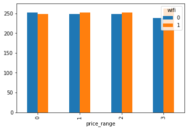

```python
plt.show(CT.plot(kind="bar"))
```

There is a slight spike in phones with wifi in the expensive category but for the most part there is minimal variance between the price ranges.

## Missing Values Check

```python
pData.isnull()
```

|  | battery_power | blue | clock_speed | dual_sim | fc | four_g | int_memory | m_dep | mobile_wt | n_cores | ... | mobile_wt_bins | px_height_bins | px_width_bins | pixel_area_000s | pixel_area_bins | screen_area | screen_area_bins | pc_bins | ram_bins | talk_time_bins |
| --- | --- | --- | --- | --- | --- | --- | --- | --- | --- | --- | --- | --- | --- | --- | --- | --- | --- | --- | --- | --- | --- |
| 0 | False | False | False | False | False | False | False | False | False | False | ... | False | False | False | False | False | False | False | False | False | False |
| 1 | False | False | False | False | False | False | False | False | False | False | ... | False | False | False | False | False | False | False | False | False | False |
| 2 | False | False | False | False | False | False | False | False | False | False | ... | False | False | False | False | False | False | False | False | False | False |
| 3 | False | False | False | False | False | False | False | False | False | False | ... | False | False | False | False | False | False | False | False | False | False |
| 4 | False | False | False | False | False | False | False | False | False | False | ... | False | False | False | False | False | False | False | False | False | False |
| ... | ... | ... | ... | ... | ... | ... | ... | ... | ... | ... | ... | ... | ... | ... | ... | ... | ... | ... | ... | ... | ... |
| 1995 | False | False | False | False | False | False | False | False | False | False | ... | False | False | False | False | False | False | False | False | False | False |
| 1996 | False | False | False | False | False | False | False | False | False | False | ... | False | False | False | False | False | False | False | False | False | False |
| 1997 | False | False | False | False | False | False | False | False | False | False | ... | False | False | False | False | False | False | False | False | False | False |
| 1998 | False | False | False | False | False | False | False | False | False | False | ... | False | False | False | False | False | False | False | False | False | False |
| 1999 | False | False | False | False | False | False | False | False | False | False | ... | False | False | False | False | False | False | False | False | False | False |

2000 rows × 36 columns

```python
pData.isnull().sum().sum()
```

```
0
```

No N/As or missing data in this data set

## Look at Correlations and Clean up data/Remove unwanted variables

#### Look at correlations between variables through correlation matrices and color maps.

```python
corr_matrix = pData.corr()
corr_matrix.style.background_gradient(cmap='coolwarm').set_precision(5)
```

|  | battery_power | blue | clock_speed | dual_sim | fc | four_g | int_memory | m_dep | mobile_wt | n_cores | pc | px_height | px_width | ram | sc_h | sc_w | talk_time | three_g | touch_screen | wifi | price_range | pixel_area_000s | screen_area |
| --- | --- | --- | --- | --- | --- | --- | --- | --- | --- | --- | --- | --- | --- | --- | --- | --- | --- | --- | --- | --- | --- | --- | --- |
| battery_power | 1.00000 | 0.01125 | 0.01148 | -0.04185 | 0.03333 | 0.01566 | -0.00400 | 0.03408 | 0.00184 | -0.02973 | 0.03144 | 0.01490 | -0.00840 | -0.00065 | -0.02996 | -0.02142 | 0.05251 | 0.01152 | -0.01052 | -0.00834 | 0.20072 | 0.01844 | -0.02459 |
| blue | 0.01125 | 1.00000 | 0.02142 | 0.03520 | 0.00359 | 0.01344 | 0.04118 | 0.00405 | -0.00860 | 0.03616 | -0.00995 | -0.00687 | -0.04153 | 0.02635 | -0.00295 | 0.00061 | 0.01393 | -0.03024 | 0.01006 | -0.02186 | 0.02057 | -0.01551 | -0.00557 |
| clock_speed | 0.01148 | 0.02142 | 1.00000 | -0.00132 | -0.00043 | -0.04307 | 0.00655 | -0.01436 | 0.01235 | -0.00572 | -0.00525 | -0.01452 | -0.00948 | 0.00344 | -0.02908 | -0.00738 | -0.01143 | -0.04643 | 0.01976 | -0.02447 | -0.00661 | -0.00985 | -0.00610 |
| dual_sim | -0.04185 | 0.03520 | -0.00132 | 1.00000 | -0.02912 | 0.00319 | -0.01568 | -0.02214 | -0.00898 | -0.02466 | -0.01714 | -0.02088 | 0.01429 | 0.04107 | -0.01195 | -0.01667 | -0.03940 | -0.01401 | -0.01712 | 0.02274 | 0.01744 | -0.01773 | -0.01570 |
| fc | 0.03333 | 0.00359 | -0.00043 | -0.02912 | 1.00000 | -0.01656 | -0.02913 | -0.00179 | 0.02362 | -0.01336 | 0.64460 | -0.00999 | -0.00518 | 0.01510 | -0.01101 | -0.01237 | -0.00683 | 0.00179 | -0.01483 | 0.02008 | 0.02200 | -0.01234 | -0.01144 |
| four_g | 0.01566 | 0.01344 | -0.04307 | 0.00319 | -0.01656 | 1.00000 | 0.00869 | -0.00182 | -0.01654 | -0.02971 | -0.00560 | -0.01924 | 0.00745 | 0.00731 | 0.02717 | 0.03700 | -0.04663 | 0.58425 | 0.01676 | -0.01762 | 0.01477 | -0.00906 | 0.03717 |
| int_memory | -0.00400 | 0.04118 | 0.00655 | -0.01568 | -0.02913 | 0.00869 | 1.00000 | 0.00689 | -0.03421 | -0.02831 | -0.03327 | 0.01044 | -0.00833 | 0.03281 | 0.03777 | 0.01173 | -0.00279 | -0.00937 | -0.02700 | 0.00699 | 0.04443 | 0.01526 | 0.02289 |
| m_dep | 0.03408 | 0.00405 | -0.01436 | -0.02214 | -0.00179 | -0.00182 | 0.00689 | 1.00000 | 0.02176 | -0.00350 | 0.02628 | 0.02526 | 0.02357 | -0.00943 | -0.02535 | -0.01839 | 0.01700 | -0.01207 | -0.00264 | -0.02835 | 0.00085 | 0.02514 | -0.02145 |
| mobile_wt | 0.00184 | -0.00860 | 0.01235 | -0.00898 | 0.02362 | -0.01654 | -0.03421 | 0.02176 | 1.00000 | -0.01899 | 0.01884 | 0.00094 | 0.00009 | -0.00258 | -0.03385 | -0.02076 | 0.00621 | 0.00155 | -0.01437 | -0.00041 | -0.03030 | -0.00604 | -0.02638 |
| n_cores | -0.02973 | 0.03616 | -0.00572 | -0.02466 | -0.01336 | -0.02971 | -0.02831 | -0.00350 | -0.01899 | 1.00000 | -0.00119 | -0.00687 | 0.02448 | 0.00487 | -0.00031 | 0.02583 | 0.01315 | -0.01473 | 0.02377 | -0.00996 | 0.00440 | 0.00125 | 0.02162 |
| pc | 0.03144 | -0.00995 | -0.00525 | -0.01714 | 0.64460 | -0.00560 | -0.03327 | 0.02628 | 0.01884 | -0.00119 | 1.00000 | -0.01847 | 0.00420 | 0.02898 | 0.00494 | -0.02382 | 0.01466 | -0.00132 | -0.00874 | 0.00539 | 0.03360 | -0.01745 | -0.01361 |
| px_height | 0.01490 | -0.00687 | -0.01452 | -0.02088 | -0.00999 | -0.01924 | 0.01044 | 0.02526 | 0.00094 | -0.00687 | -0.01847 | 1.00000 | 0.51066 | -0.02035 | 0.05962 | 0.04304 | -0.01065 | -0.03117 | 0.02189 | 0.05182 | 0.14886 | 0.95273 | 0.05389 |
| px_width | -0.00840 | -0.04153 | -0.00948 | 0.01429 | -0.00518 | 0.00745 | -0.00833 | 0.02357 | 0.00009 | 0.02448 | 0.00420 | 0.51066 | 1.00000 | 0.00411 | 0.02160 | 0.03470 | 0.00672 | 0.00035 | -0.00163 | 0.03032 | 0.16582 | 0.68406 | 0.04135 |
| ram | -0.00065 | 0.02635 | 0.00344 | 0.04107 | 0.01510 | 0.00731 | 0.03281 | -0.00943 | -0.00258 | 0.00487 | 0.02898 | -0.02035 | 0.00411 | 1.00000 | 0.01600 | 0.03558 | 0.01082 | 0.01579 | -0.03045 | 0.02267 | 0.91705 | -0.00636 | 0.03333 |
| sc_h | -0.02996 | -0.00295 | -0.02908 | -0.01195 | -0.01101 | 0.02717 | 0.03777 | -0.02535 | -0.03385 | -0.00031 | 0.00494 | 0.05962 | 0.02160 | 0.01600 | 1.00000 | 0.50614 | -0.01734 | 0.01203 | -0.02002 | 0.02593 | 0.02299 | 0.05836 | 0.65603 |
| sc_w | -0.02142 | 0.00061 | -0.00738 | -0.01667 | -0.01237 | 0.03700 | 0.01173 | -0.01839 | -0.02076 | 0.02583 | -0.02382 | 0.04304 | 0.03470 | 0.03558 | 0.50614 | 1.00000 | -0.02282 | 0.03094 | 0.01272 | 0.03542 | 0.03871 | 0.04650 | 0.95962 |
| talk_time | 0.05251 | 0.01393 | -0.01143 | -0.03940 | -0.00683 | -0.04663 | -0.00279 | 0.01700 | 0.00621 | 0.01315 | 0.01466 | -0.01065 | 0.00672 | 0.01082 | -0.01734 | -0.02282 | 1.00000 | -0.04269 | 0.01720 | -0.02950 | 0.02186 | -0.01073 | -0.02650 |
| three_g | 0.01152 | -0.03024 | -0.04643 | -0.01401 | 0.00179 | 0.58425 | -0.00937 | -0.01207 | 0.00155 | -0.01473 | -0.00132 | -0.03117 | 0.00035 | 0.01579 | 0.01203 | 0.03094 | -0.04269 | 1.00000 | 0.01392 | 0.00432 | 0.02361 | -0.02822 | 0.03360 |
| touch_screen | -0.01052 | 0.01006 | 0.01976 | -0.01712 | -0.01483 | 0.01676 | -0.02700 | -0.00264 | -0.01437 | 0.02377 | -0.00874 | 0.02189 | -0.00163 | -0.03045 | -0.02002 | 0.01272 | 0.01720 | 0.01392 | 1.00000 | 0.01192 | -0.03041 | 0.01704 | 0.00813 |
| wifi | -0.00834 | -0.02186 | -0.02447 | 0.02274 | 0.02008 | -0.01762 | 0.00699 | -0.02835 | -0.00041 | -0.00996 | 0.00539 | 0.05182 | 0.03032 | 0.02267 | 0.02593 | 0.03542 | -0.02950 | 0.00432 | 0.01192 | 1.00000 | 0.01878 | 0.04448 | 0.04359 |
| price_range | 0.20072 | 0.02057 | -0.00661 | 0.01744 | 0.02200 | 0.01477 | 0.04443 | 0.00085 | -0.03030 | 0.00440 | 0.03360 | 0.14886 | 0.16582 | 0.91705 | 0.02299 | 0.03871 | 0.02186 | 0.02361 | -0.03041 | 0.01878 | 1.00000 | 0.17624 | 0.04125 |
| pixel_area_000s | 0.01844 | -0.01551 | -0.00985 | -0.01773 | -0.01234 | -0.00906 | 0.01526 | 0.02514 | -0.00604 | 0.00125 | -0.01745 | 0.95273 | 0.68406 | -0.00636 | 0.05836 | 0.04650 | -0.01073 | -0.02822 | 0.01704 | 0.04448 | 0.17624 | 1.00000 | 0.05700 |
| screen_area | -0.02459 | -0.00557 | -0.00610 | -0.01570 | -0.01144 | 0.03717 | 0.02289 | -0.02145 | -0.02638 | 0.02162 | -0.01361 | 0.05389 | 0.04135 | 0.03333 | 0.65603 | 0.95962 | -0.02650 | 0.03360 | 0.00813 | 0.04359 | 0.04125 | 0.05700 | 1.00000 |

3G and 4G are somewhat highly and postively correlated with a correlation value of .58425. Since 4G is newer technology we will remove 3G and move forward with 4G as a potential indicator

```python
pDataFinal = pData.drop("three_g", axis=1)
corr_matrix = pDataFinal.corr()
corr_matrix.style.background_gradient(cmap='coolwarm').set_precision(5)
```

|  | battery_power | blue | clock_speed | dual_sim | fc | four_g | int_memory | m_dep | mobile_wt | n_cores | pc | px_height | px_width | ram | sc_h | sc_w | talk_time | touch_screen | wifi | price_range | pixel_area_000s | screen_area |
| --- | --- | --- | --- | --- | --- | --- | --- | --- | --- | --- | --- | --- | --- | --- | --- | --- | --- | --- | --- | --- | --- | --- |
| battery_power | 1.00000 | 0.01125 | 0.01148 | -0.04185 | 0.03333 | 0.01566 | -0.00400 | 0.03408 | 0.00184 | -0.02973 | 0.03144 | 0.01490 | -0.00840 | -0.00065 | -0.02996 | -0.02142 | 0.05251 | -0.01052 | -0.00834 | 0.20072 | 0.01844 | -0.02459 |
| blue | 0.01125 | 1.00000 | 0.02142 | 0.03520 | 0.00359 | 0.01344 | 0.04118 | 0.00405 | -0.00860 | 0.03616 | -0.00995 | -0.00687 | -0.04153 | 0.02635 | -0.00295 | 0.00061 | 0.01393 | 0.01006 | -0.02186 | 0.02057 | -0.01551 | -0.00557 |
| clock_speed | 0.01148 | 0.02142 | 1.00000 | -0.00132 | -0.00043 | -0.04307 | 0.00655 | -0.01436 | 0.01235 | -0.00572 | -0.00525 | -0.01452 | -0.00948 | 0.00344 | -0.02908 | -0.00738 | -0.01143 | 0.01976 | -0.02447 | -0.00661 | -0.00985 | -0.00610 |
| dual_sim | -0.04185 | 0.03520 | -0.00132 | 1.00000 | -0.02912 | 0.00319 | -0.01568 | -0.02214 | -0.00898 | -0.02466 | -0.01714 | -0.02088 | 0.01429 | 0.04107 | -0.01195 | -0.01667 | -0.03940 | -0.01712 | 0.02274 | 0.01744 | -0.01773 | -0.01570 |
| fc | 0.03333 | 0.00359 | -0.00043 | -0.02912 | 1.00000 | -0.01656 | -0.02913 | -0.00179 | 0.02362 | -0.01336 | 0.64460 | -0.00999 | -0.00518 | 0.01510 | -0.01101 | -0.01237 | -0.00683 | -0.01483 | 0.02008 | 0.02200 | -0.01234 | -0.01144 |
| four_g | 0.01566 | 0.01344 | -0.04307 | 0.00319 | -0.01656 | 1.00000 | 0.00869 | -0.00182 | -0.01654 | -0.02971 | -0.00560 | -0.01924 | 0.00745 | 0.00731 | 0.02717 | 0.03700 | -0.04663 | 0.01676 | -0.01762 | 0.01477 | -0.00906 | 0.03717 |
| int_memory | -0.00400 | 0.04118 | 0.00655 | -0.01568 | -0.02913 | 0.00869 | 1.00000 | 0.00689 | -0.03421 | -0.02831 | -0.03327 | 0.01044 | -0.00833 | 0.03281 | 0.03777 | 0.01173 | -0.00279 | -0.02700 | 0.00699 | 0.04443 | 0.01526 | 0.02289 |
| m_dep | 0.03408 | 0.00405 | -0.01436 | -0.02214 | -0.00179 | -0.00182 | 0.00689 | 1.00000 | 0.02176 | -0.00350 | 0.02628 | 0.02526 | 0.02357 | -0.00943 | -0.02535 | -0.01839 | 0.01700 | -0.00264 | -0.02835 | 0.00085 | 0.02514 | -0.02145 |
| mobile_wt | 0.00184 | -0.00860 | 0.01235 | -0.00898 | 0.02362 | -0.01654 | -0.03421 | 0.02176 | 1.00000 | -0.01899 | 0.01884 | 0.00094 | 0.00009 | -0.00258 | -0.03385 | -0.02076 | 0.00621 | -0.01437 | -0.00041 | -0.03030 | -0.00604 | -0.02638 |
| n_cores | -0.02973 | 0.03616 | -0.00572 | -0.02466 | -0.01336 | -0.02971 | -0.02831 | -0.00350 | -0.01899 | 1.00000 | -0.00119 | -0.00687 | 0.02448 | 0.00487 | -0.00031 | 0.02583 | 0.01315 | 0.02377 | -0.00996 | 0.00440 | 0.00125 | 0.02162 |
| pc | 0.03144 | -0.00995 | -0.00525 | -0.01714 | 0.64460 | -0.00560 | -0.03327 | 0.02628 | 0.01884 | -0.00119 | 1.00000 | -0.01847 | 0.00420 | 0.02898 | 0.00494 | -0.02382 | 0.01466 | -0.00874 | 0.00539 | 0.03360 | -0.01745 | -0.01361 |
| px_height | 0.01490 | -0.00687 | -0.01452 | -0.02088 | -0.00999 | -0.01924 | 0.01044 | 0.02526 | 0.00094 | -0.00687 | -0.01847 | 1.00000 | 0.51066 | -0.02035 | 0.05962 | 0.04304 | -0.01065 | 0.02189 | 0.05182 | 0.14886 | 0.95273 | 0.05389 |
| px_width | -0.00840 | -0.04153 | -0.00948 | 0.01429 | -0.00518 | 0.00745 | -0.00833 | 0.02357 | 0.00009 | 0.02448 | 0.00420 | 0.51066 | 1.00000 | 0.00411 | 0.02160 | 0.03470 | 0.00672 | -0.00163 | 0.03032 | 0.16582 | 0.68406 | 0.04135 |
| ram | -0.00065 | 0.02635 | 0.00344 | 0.04107 | 0.01510 | 0.00731 | 0.03281 | -0.00943 | -0.00258 | 0.00487 | 0.02898 | -0.02035 | 0.00411 | 1.00000 | 0.01600 | 0.03558 | 0.01082 | -0.03045 | 0.02267 | 0.91705 | -0.00636 | 0.03333 |
| sc_h | -0.02996 | -0.00295 | -0.02908 | -0.01195 | -0.01101 | 0.02717 | 0.03777 | -0.02535 | -0.03385 | -0.00031 | 0.00494 | 0.05962 | 0.02160 | 0.01600 | 1.00000 | 0.50614 | -0.01734 | -0.02002 | 0.02593 | 0.02299 | 0.05836 | 0.65603 |
| sc_w | -0.02142 | 0.00061 | -0.00738 | -0.01667 | -0.01237 | 0.03700 | 0.01173 | -0.01839 | -0.02076 | 0.02583 | -0.02382 | 0.04304 | 0.03470 | 0.03558 | 0.50614 | 1.00000 | -0.02282 | 0.01272 | 0.03542 | 0.03871 | 0.04650 | 0.95962 |
| talk_time | 0.05251 | 0.01393 | -0.01143 | -0.03940 | -0.00683 | -0.04663 | -0.00279 | 0.01700 | 0.00621 | 0.01315 | 0.01466 | -0.01065 | 0.00672 | 0.01082 | -0.01734 | -0.02282 | 1.00000 | 0.01720 | -0.02950 | 0.02186 | -0.01073 | -0.02650 |
| touch_screen | -0.01052 | 0.01006 | 0.01976 | -0.01712 | -0.01483 | 0.01676 | -0.02700 | -0.00264 | -0.01437 | 0.02377 | -0.00874 | 0.02189 | -0.00163 | -0.03045 | -0.02002 | 0.01272 | 0.01720 | 1.00000 | 0.01192 | -0.03041 | 0.01704 | 0.00813 |
| wifi | -0.00834 | -0.02186 | -0.02447 | 0.02274 | 0.02008 | -0.01762 | 0.00699 | -0.02835 | -0.00041 | -0.00996 | 0.00539 | 0.05182 | 0.03032 | 0.02267 | 0.02593 | 0.03542 | -0.02950 | 0.01192 | 1.00000 | 0.01878 | 0.04448 | 0.04359 |
| price_range | 0.20072 | 0.02057 | -0.00661 | 0.01744 | 0.02200 | 0.01477 | 0.04443 | 0.00085 | -0.03030 | 0.00440 | 0.03360 | 0.14886 | 0.16582 | 0.91705 | 0.02299 | 0.03871 | 0.02186 | -0.03041 | 0.01878 | 1.00000 | 0.17624 | 0.04125 |
| pixel_area_000s | 0.01844 | -0.01551 | -0.00985 | -0.01773 | -0.01234 | -0.00906 | 0.01526 | 0.02514 | -0.00604 | 0.00125 | -0.01745 | 0.95273 | 0.68406 | -0.00636 | 0.05836 | 0.04650 | -0.01073 | 0.01704 | 0.04448 | 0.17624 | 1.00000 | 0.05700 |
| screen_area | -0.02459 | -0.00557 | -0.00610 | -0.01570 | -0.01144 | 0.03717 | 0.02289 | -0.02145 | -0.02638 | 0.02162 | -0.01361 | 0.05389 | 0.04135 | 0.03333 | 0.65603 | 0.95962 | -0.02650 | 0.00813 | 0.04359 | 0.04125 | 0.05700 | 1.00000 |

As expected, the pixel height and width is high positively correlated with the engineered feature pixel_area_000s and the screen area is highly correlated with sc_h and sc_w. We will remove the original variables which indicate the indivudal heights and widths.

```python
pDataFinal = pDataFinal.drop(["px_height","px_width", "sc_h", "sc_w"], axis=1)
corr_matrix = pDataFinal.corr()
corr_matrix.style.background_gradient(cmap='coolwarm').set_precision(5)
```

|  | battery_power | blue | clock_speed | dual_sim | fc | four_g | int_memory | m_dep | mobile_wt | n_cores | pc | ram | talk_time | touch_screen | wifi | price_range | pixel_area_000s | screen_area |
| --- | --- | --- | --- | --- | --- | --- | --- | --- | --- | --- | --- | --- | --- | --- | --- | --- | --- | --- |
| battery_power | 1.00000 | 0.01125 | 0.01148 | -0.04185 | 0.03333 | 0.01566 | -0.00400 | 0.03408 | 0.00184 | -0.02973 | 0.03144 | -0.00065 | 0.05251 | -0.01052 | -0.00834 | 0.20072 | 0.01844 | -0.02459 |
| blue | 0.01125 | 1.00000 | 0.02142 | 0.03520 | 0.00359 | 0.01344 | 0.04118 | 0.00405 | -0.00860 | 0.03616 | -0.00995 | 0.02635 | 0.01393 | 0.01006 | -0.02186 | 0.02057 | -0.01551 | -0.00557 |
| clock_speed | 0.01148 | 0.02142 | 1.00000 | -0.00132 | -0.00043 | -0.04307 | 0.00655 | -0.01436 | 0.01235 | -0.00572 | -0.00525 | 0.00344 | -0.01143 | 0.01976 | -0.02447 | -0.00661 | -0.00985 | -0.00610 |
| dual_sim | -0.04185 | 0.03520 | -0.00132 | 1.00000 | -0.02912 | 0.00319 | -0.01568 | -0.02214 | -0.00898 | -0.02466 | -0.01714 | 0.04107 | -0.03940 | -0.01712 | 0.02274 | 0.01744 | -0.01773 | -0.01570 |
| fc | 0.03333 | 0.00359 | -0.00043 | -0.02912 | 1.00000 | -0.01656 | -0.02913 | -0.00179 | 0.02362 | -0.01336 | 0.64460 | 0.01510 | -0.00683 | -0.01483 | 0.02008 | 0.02200 | -0.01234 | -0.01144 |
| four_g | 0.01566 | 0.01344 | -0.04307 | 0.00319 | -0.01656 | 1.00000 | 0.00869 | -0.00182 | -0.01654 | -0.02971 | -0.00560 | 0.00731 | -0.04663 | 0.01676 | -0.01762 | 0.01477 | -0.00906 | 0.03717 |
| int_memory | -0.00400 | 0.04118 | 0.00655 | -0.01568 | -0.02913 | 0.00869 | 1.00000 | 0.00689 | -0.03421 | -0.02831 | -0.03327 | 0.03281 | -0.00279 | -0.02700 | 0.00699 | 0.04443 | 0.01526 | 0.02289 |
| m_dep | 0.03408 | 0.00405 | -0.01436 | -0.02214 | -0.00179 | -0.00182 | 0.00689 | 1.00000 | 0.02176 | -0.00350 | 0.02628 | -0.00943 | 0.01700 | -0.00264 | -0.02835 | 0.00085 | 0.02514 | -0.02145 |
| mobile_wt | 0.00184 | -0.00860 | 0.01235 | -0.00898 | 0.02362 | -0.01654 | -0.03421 | 0.02176 | 1.00000 | -0.01899 | 0.01884 | -0.00258 | 0.00621 | -0.01437 | -0.00041 | -0.03030 | -0.00604 | -0.02638 |
| n_cores | -0.02973 | 0.03616 | -0.00572 | -0.02466 | -0.01336 | -0.02971 | -0.02831 | -0.00350 | -0.01899 | 1.00000 | -0.00119 | 0.00487 | 0.01315 | 0.02377 | -0.00996 | 0.00440 | 0.00125 | 0.02162 |
| pc | 0.03144 | -0.00995 | -0.00525 | -0.01714 | 0.64460 | -0.00560 | -0.03327 | 0.02628 | 0.01884 | -0.00119 | 1.00000 | 0.02898 | 0.01466 | -0.00874 | 0.00539 | 0.03360 | -0.01745 | -0.01361 |
| ram | -0.00065 | 0.02635 | 0.00344 | 0.04107 | 0.01510 | 0.00731 | 0.03281 | -0.00943 | -0.00258 | 0.00487 | 0.02898 | 1.00000 | 0.01082 | -0.03045 | 0.02267 | 0.91705 | -0.00636 | 0.03333 |
| talk_time | 0.05251 | 0.01393 | -0.01143 | -0.03940 | -0.00683 | -0.04663 | -0.00279 | 0.01700 | 0.00621 | 0.01315 | 0.01466 | 0.01082 | 1.00000 | 0.01720 | -0.02950 | 0.02186 | -0.01073 | -0.02650 |
| touch_screen | -0.01052 | 0.01006 | 0.01976 | -0.01712 | -0.01483 | 0.01676 | -0.02700 | -0.00264 | -0.01437 | 0.02377 | -0.00874 | -0.03045 | 0.01720 | 1.00000 | 0.01192 | -0.03041 | 0.01704 | 0.00813 |
| wifi | -0.00834 | -0.02186 | -0.02447 | 0.02274 | 0.02008 | -0.01762 | 0.00699 | -0.02835 | -0.00041 | -0.00996 | 0.00539 | 0.02267 | -0.02950 | 0.01192 | 1.00000 | 0.01878 | 0.04448 | 0.04359 |
| price_range | 0.20072 | 0.02057 | -0.00661 | 0.01744 | 0.02200 | 0.01477 | 0.04443 | 0.00085 | -0.03030 | 0.00440 | 0.03360 | 0.91705 | 0.02186 | -0.03041 | 0.01878 | 1.00000 | 0.17624 | 0.04125 |
| pixel_area_000s | 0.01844 | -0.01551 | -0.00985 | -0.01773 | -0.01234 | -0.00906 | 0.01526 | 0.02514 | -0.00604 | 0.00125 | -0.01745 | -0.00636 | -0.01073 | 0.01704 | 0.04448 | 0.17624 | 1.00000 | 0.05700 |
| screen_area | -0.02459 | -0.00557 | -0.00610 | -0.01570 | -0.01144 | 0.03717 | 0.02289 | -0.02145 | -0.02638 | 0.02162 | -0.01361 | 0.03333 | -0.02650 | 0.00813 | 0.04359 | 0.04125 | 0.05700 | 1.00000 |

A general observation is the high correlation between the target variable, price_range, and the ram variable. This was expected during exploratory analysis but theis correlation table confirms it.

There is also a significant correlation between primary camera megapixels and front facing camera pixels. Given that the technology of a simple camera on a phone versus a front facing camera on a phone was released at different points in time, we will keep both variables. There may be a way we can create a feature that captures both of those features.

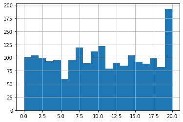

```python
pData["pc"].hist(bins=20)
```

```python
pData["fc"].hist(bins=20)
```

[output not shown]

```python
pDataFinal.columns
```

[output not shown]

We will keep the original variables in the data as opposed to keeping the feature engineered bin variables.

```python
pDataFinal = pDataFinal.drop(['battery_power_bins',
       'clock_speed_bins', 'fc_bins', 'int_memory_bins', 'm_dep_bins',
       'mobile_wt_bins', 'px_height_bins', 'px_width_bins', 'pixel_area_000s',
       'pixel_area_bins', 'screen_area', 'screen_area_bins', 'pc_bins',
       'ram_bins', 'talk_time_bins'], axis=1)
```

```python
pDataFinal
```

[output not shown]

```python
corr_matrix = pDataFinal.corr()
corr_matrix.style.background_gradient(cmap='coolwarm').set_precision(5)
```

[output not shown]

## Split the data into random training and testing sets

```python
pDataFinalX = pDataFinal.loc[:, pDataFinal.columns != 'price_range']
pDataFinalX.columns
```

[output not shown]

```python
pDataFinalY = pDataFinal.loc[:, pDataFinal.columns == 'price_range']
pDataFinalY.columns
```

[output not shown]

```python
train_data, test_data, train_target, test_target = train_test_split(pDataFinalX, pDataFinalY, test_size = .2)
```

```python
train_data.shape
```

[output not shown]

```python
test_data.shape
```

[output not shown]

```python
train_target.shape
```

[output not shown]

```python
test_target.shape
```

[output not shown]

## Perform Transformations

#### Normalize the data with z-score normalization.

#### Create dummy variables or discretizing features if necessary too

```python
cols = train_data.columns
train_data_z=zscore(train_data,axis=1)
train_data_z = pd.DataFrame(train_data_z, columns = cols)

cols = test_data.columns
test_data_z=zscore(test_data,axis=1)
test_data_z = pd.DataFrame(test_data_z, columns = cols)
```

```python
train_data_z.describe()
```

[output not shown]

```python
test_data_z.describe()
```

[output not shown]

```python
train_target
```

[output not shown]

```python
test_target
```

[output not shown]

## Export the Data

```python
train_data_z.to_csv('../data/train_data_z.csv')
test_data_z.to_csv('../data/test_data_z.csv')
train_target.to_csv('../data/train_target.csv')
test_target.to_csv('../data/test_target.csv')
```